[figure not shown]

# Quality Control Report

# **scFlow** - Quality Control Report

10 January, 2023

## Overview

### Post-QC Summary

- Cells 224
- Genes 3,329
- Total counts (M) 2070.5
- Total features (M) 1083
- Mitochondrial counts (M%) 0.00%
- Ribosomal counts (M%) 7.40%

* M is the median for QC-passed cells

### Key Parameters

- Library size 100 – 5,997
- Features/Genes 100 – 2,827
- Max. Mito. Counts 0.0%
- Ribo. Counts 0.0% – 100.0%
- Drop Mito. Genes Yes
- Drop Ribo. Genes No

### Steps

Metadata Imported ✔️ Ambient RNA / EmptyDrops Run ❌ Thresholding ✔️ ️ Gene/Cell QC Metric Annotation ✔️ ️ Doublets/Multiplets Identified ❌

## Sample metadata

A total of 5 metadata variables were imported from the sample sheet for this sample: -

| metadata | class | values |
| --- | --- | --- |
| manifest | factor | jafap |
| individual | factor | 3 |
| diagnosis | factor | Case |
| sex | factor | M |
| age | integer | 6 |

## Empty droplet identification

EmptyDrops was not run on this dataset.

## Count depth distribution by barcode rank (high to low counts)

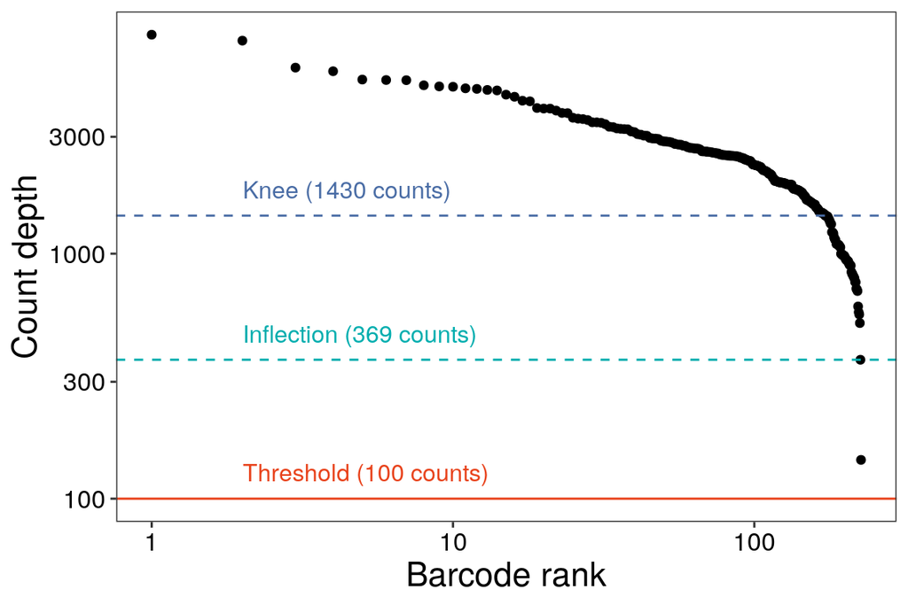

**Figure: Barcode count depth rank plot.** The ‘elbow’ indicates where count depth decreases rapidly (relative increase in background counts), and can be used to inform the count depth threshold. The applied lower-limit counts threshold is indicated at 100 counts (red line).

## Number of counts / features per cellular barcode

The maximum number of counts per cell threshold was determined adaptively for this sample as >=4 median average deviations (MADs), or 5997 total counts per cell. The maximum number of features per cell threshold was determined adaptively for this sample as >=4 median average deviations (MADs), or 2827 total features per cell.

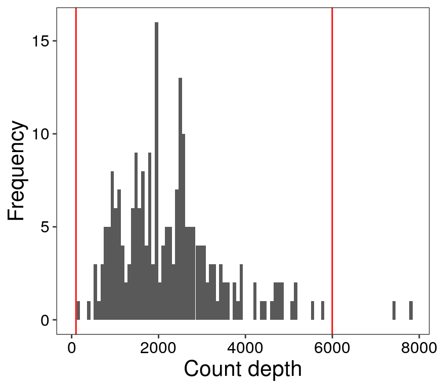

**Figure: Histogram of count depth per cell.** A lower-limit threshold of 100 and an upper-limit threshold of 5997 was applied (red line).

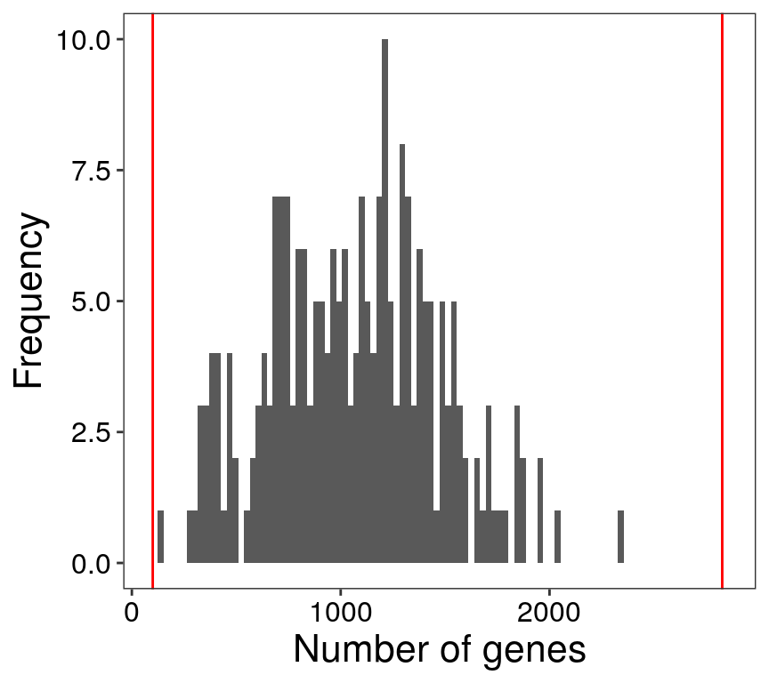

**Figure: Histogram of number of genes per cell.** A lower-limit threshold of 100 and an upper-limit threshold of 2827 was applied (red line).

## Number of genes versus count depth

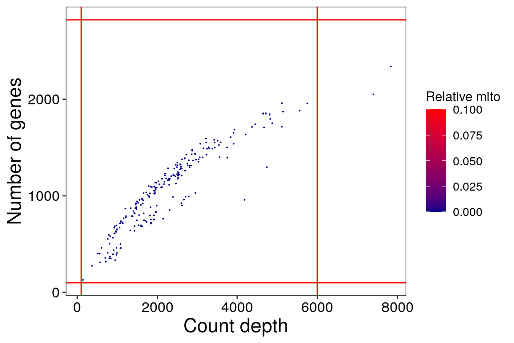

**Figure: Number of genes versus count depth coloured by relative mitochondrial counts.** The count-depth threshold of 100 – 5997 counts and the number of genes threshold of 100 – 2827 genes are indicated with vertical and horizontal red lines, respectively. Cells with high mitochondrial counts are typically in cells with relatively lower count depth. Cells with fractional mitochondrial counts higher than 0.000 (i.e. 0.00%) were filtered.

## Fraction of mitochondrial / ribosomal counts

The maximum fraction of mitochondrial counts per cell threshold was determined adaptively for this sample as >=4 median average deviations (MADs), or 0 total counts per cell.

[figure not shown]

**Figure: Histogram of mitochondrial fraction per cell.** An upper-threshold of 0.000 (i.e. 0.00%) maximum mitochondrial fraction was applied (red line).

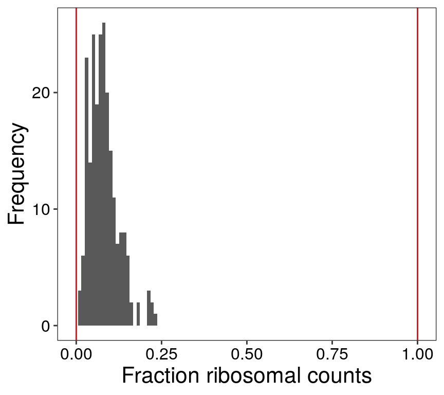

**Figure: Histogram of ribosomal fraction per cell.** An upper-threshold of 1 (i.e. 100.00%) maximum ribosomal fraction was applied (red line).

## Doublet/multiplet identification

No doublet/multiplet identification algorithm was run on this dataset.

## Full QC parameters and results

| qc_params_min_library_size | 100 |
| --- | --- |
| qc_params_max_library_size | 5997 |
| qc_params_min_features | 100 |
| qc_params_max_features | 2827 |
| qc_params_max_mito | 0 |
| qc_params_min_ribo | 0 |
| qc_params_max_ribo | 1 |
| qc_params_min_counts | 2 |
| qc_params_min_cells | 2 |
| qc_params_drop_unmapped | TRUE |

[output cut: 45 more lines]

## References

scFlow v0.7.1 – 2023-01-10 15:13:59

A report by **scFlow**